# Raven_Shaw_Final

## **Introduction to Data Science Class**

### **Final Project: Introduction to Data Analysis**

### ***"Global Housing Market Dynamics Amid the COVID-19 Pandemic: A Data Driven Analysis"***

**Raven Shaw**  
**Student ID: 003099620**  
**Tuesday, April 29, 2025**

#### **Introduction and Background:**

This project aims to analyze global housing market trends during the COVID-19 pandemic, focusing on factors such as affordability, the house price index, urbanization, population growth, GDP, and inflation across different regions.

By examining housing market data of the years 2020 and 2023, the analysis seeks to explore how the pandemic may have acted as an externality influencing the patterns observed. Overall, the findings will provide insights into both the short- and long-term impacts of global crises on real estate markets.

**"Global Housing Market Analysis (2015-2024)" Dataset**: [Click here to view the orginal dataset source](https://www.kaggle.com/datasets/atharvasoundankar/global-housing-market-analysis-2015-2024?select=global_housing_market_extended.csv)

#### **Section 1: Understanding Dataset**

```python
# Import the Libraries
import pandas as pd
import numpy as np
import seaborn as sns
import matplotlib.pyplot as plt
import plotly.express as px
```

```python
df = pd.read_csv("global_housing_market.csv") #importing the dataset
df #display data
```

|  | Country | Year | House Price Index | Rent Index | Affordability Ratio | Mortgage Rate (%) | Inflation Rate (%) | GDP Growth (%) | Population Growth (%) | Urbanization Rate (%) | Construction Index |
| --- | --- | --- | --- | --- | --- | --- | --- | --- | --- | --- | --- |
| 0 | USA | 2015 | 117.454012 | 116.550001 | 9.587945 | 4.493292 | 1.514121 | -0.752044 | -0.796707 | 85.985284 | 118.089201 |
| 1 | USA | 2016 | 150.807258 | 51.440915 | 11.729189 | 5.662213 | 1.880204 | -0.545400 | -0.358084 | 69.127267 | 111.980515 |
| 2 | USA | 2017 | 123.194502 | 70.386040 | 8.506676 | 2.197469 | 2.398940 | 0.930895 | 0.596245 | 83.555279 | 85.973903 |
| 3 | USA | 2018 | 131.423444 | 91.469020 | 3.418054 | 4.537724 | 1.608407 | -1.479587 | 2.321099 | 88.968961 | 134.671788 |
| 4 | USA | 2019 | 110.461377 | 56.837048 | 9.158097 | 3.700762 | 1.293249 | 1.961415 | -0.879640 | 87.279612 | 90.702399 |
| ... | ... | ... | ... | ... | ... | ... | ... | ... | ... | ... | ... |
| 195 | UAE | 2020 | 160.153711 | 117.170365 | 7.390686 | 2.048681 | 4.061737 | 1.635019 | 1.955250 | 62.942477 | 109.059291 |
| 196 | UAE | 2021 | 95.004866 | 72.727315 | 9.636214 | 3.880091 | 2.943274 | 1.155810 | 0.608064 | 83.550496 | 141.366775 |
| 197 | UAE | 2022 | 175.533469 | 105.083237 | 5.838662 | 4.940674 | 3.344420 | 0.037365 | 1.943051 | 61.152790 | 142.140959 |
| 198 | UAE | 2023 | 126.147746 | 94.604103 | 8.934185 | 5.975589 | 4.638353 | 2.911469 | -0.766718 | 75.552241 | 82.013520 |
| 199 | UAE | 2024 | 153.743377 | 85.855534 | 9.122050 | 1.708365 | 1.051148 | 3.730587 | -0.747705 | 62.137702 | 70.968678 |

200 rows × 11 columns

```python
print(df.head()) #show first five rows
```

```
  Country  Year  House Price Index  Rent Index  Affordability Ratio  \
0     USA  2015         117.454012  116.550001             9.587945
1     USA  2016         150.807258   51.440915            11.729189
2     USA  2017         123.194502   70.386040             8.506676
3     USA  2018         131.423444   91.469020             3.418054
4     USA  2019         110.461377   56.837048             9.158097

   Mortgage Rate (%)  Inflation Rate (%)  GDP Growth (%)  \
0           4.493292            1.514121       -0.752044
1           5.662213            1.880204       -0.545400
2           2.197469            2.398940        0.930895
3           4.537724            1.608407       -1.479587
4           3.700762            1.293249        1.961415

   Population Growth (%)  Urbanization Rate (%)  Construction Index
0              -0.796707              85.985284          118.089201
1              -0.358084              69.127267          111.980515
2               0.596245              83.555279           85.973903
3               2.321099              88.968961          134.671788
4              -0.879640              87.279612           90.702399
```

```python
print(df.tail()) #show last five rows
```

```
    Country  Year  House Price Index  Rent Index  Affordability Ratio  \
195     UAE  2020         160.153711  117.170365             7.390686
196     UAE  2021          95.004866   72.727315             9.636214
197     UAE  2022         175.533469  105.083237             5.838662
198     UAE  2023         126.147746   94.604103             8.934185
199     UAE  2024         153.743377   85.855534             9.122050

     Mortgage Rate (%)  Inflation Rate (%)  GDP Growth (%)  \
195           2.048681            4.061737        1.635019
196           3.880091            2.943274        1.155810
197           4.940674            3.344420        0.037365
198           5.975589            4.638353        2.911469
199           1.708365            1.051148        3.730587

     Population Growth (%)  Urbanization Rate (%)  Construction Index
195               1.955250              62.942477          109.059291
196               0.608064              83.550496          141.366775
197               1.943051              61.152790          142.140959
198              -0.766718              75.552241           82.013520
199              -0.747705              62.137702           70.968678
```

```python
df.info #displaying general information about the data
```

```
<bound method DataFrame.info of     Country  Year  House Price Index  Rent Index  Affordability Ratio  \
0       USA  2015         117.454012  116.550001             9.587945
1       USA  2016         150.807258   51.440915            11.729189
2       USA  2017         123.194502   70.386040             8.506676
3       USA  2018         131.423444   91.469020             3.418054
4       USA  2019         110.461377   56.837048             9.158097
..      ...   ...                ...         ...                  ...
195     UAE  2020         160.153711  117.170365             7.390686
196     UAE  2021          95.004866   72.727315             9.636214
197     UAE  2022         175.533469  105.083237             5.838662
198     UAE  2023         126.147746   94.604103             8.934185
199     UAE  2024         153.743377   85.855534             9.122050

     Mortgage Rate (%)  Inflation Rate (%)  GDP Growth (%)  \
0             4.493292            1.514121       -0.752044
```

[output cut: 25 more lines]

```python
df.shape #see number of rows and columns (respectively)
```

```
(200, 11)
```

```python
df.columns #displaying only column names
```

```
Index(['Country', 'Year', 'House Price Index', 'Rent Index',
       'Affordability Ratio', 'Mortgage Rate (%)', 'Inflation Rate (%)',
       'GDP Growth (%)', 'Population Growth (%)', 'Urbanization Rate (%)',
       'Construction Index'],
      dtype='object')
```

```python
print(df.dtypes) #viewing datatypes
```

```
Country                   object
Year                       int64
House Price Index        float64
Rent Index               float64
Affordability Ratio      float64
Mortgage Rate (%)        float64
Inflation Rate (%)       float64
GDP Growth (%)           float64
Population Growth (%)    float64
Urbanization Rate (%)    float64
Construction Index       float64
dtype: object
```

```python
print(df.isnull().sum()) #Checking for null values
```

```
Country                  0
Year                     0
House Price Index        0
Rent Index               0
Affordability Ratio      0
Mortgage Rate (%)        0
Inflation Rate (%)       0
GDP Growth (%)           0
Population Growth (%)    0
Urbanization Rate (%)    0
Construction Index       0
dtype: int64
```

***Section 1 Explanation:*** I began by importing the libraries "numpy" and "pandas" and setting them equal to the variables "np" and "pd" respectively. I then imported my csv (ensuring it was downloaded into the correct folder on my desktop) by using the "read_csv" function and setting the dataset equal to the variable "df." I then sought to gain an overview of my data by using various functions such as "describe", "head", "tail," "type," "shape," and "columns." This allowed me to understand my dataset more clearly. From there I checked the number of null values and fortunately, there are none.

#### **Section 2: Cleaning Requirements**

```python
df_new=df.copy() #copying dataset into new dataframe
```

```python
df_new.duplicated().sum() #checking for duplicates
```

```
0
```

```python
df_new.drop(columns=['Construction Index'], inplace=True) #dropping Construction Index column
```

```python
df_new['Year_cat'] = df_new['Year'].astype('category') #converting 'Year' column from integer into category data type
print(df_new.dtypes) #display all datatypes of columns
```

```
Country                    object
Year                        int64
House Price Index         float64
Rent Index                float64
Affordability Ratio       float64
Mortgage Rate (%)         float64
Inflation Rate (%)        float64
GDP Growth (%)            float64
Population Growth (%)     float64
Urbanization Rate (%)     float64
Year_cat                 category
dtype: object
```

```python
df_updated = df_new.copy() #saving changes by copying 'df_new' into new dataframe 'df_updated'
```

```python
df_updated.describe() #ensuring numeric columns are valid
```

|  | Year | House Price Index | Rent Index | Affordability Ratio | Mortgage Rate (%) | Inflation Rate (%) | GDP Growth (%) | Population Growth (%) | Urbanization Rate (%) |
| --- | --- | --- | --- | --- | --- | --- | --- | --- | --- |
| count | 200.000000 | 200.000000 | 200.000000 | 200.000000 | 200.000000 | 200.000000 | 200.000000 | 200.000000 | 200.000000 |
| mean | 2019.500000 | 130.381022 | 83.048370 | 7.237768 | 4.150621 | 3.649756 | 2.133722 | 0.722806 | 74.769891 |
| std | 2.879489 | 28.752229 | 21.439858 | 2.576085 | 1.380222 | 1.881938 | 2.413270 | 1.035691 | 8.734246 |
| min | 2015.000000 | 80.552212 | 50.354311 | 3.041688 | 1.537814 | 0.532110 | -1.921833 | -0.961391 | 60.172760 |
| 25% | 2017.000000 | 104.142562 | 60.466671 | 5.034207 | 3.045278 | 1.939199 | -0.095628 | -0.183320 | 66.923842 |
| 50% | 2019.500000 | 129.193653 | 83.721711 | 7.375697 | 4.329643 | 3.664625 | 2.307548 | 0.722372 | 75.100060 |
| 75% | 2022.000000 | 157.127098 | 100.604665 | 9.276196 | 5.217706 | 5.261720 | 4.272776 | 1.621317 | 82.677430 |
| max | 2024.000000 | 179.971767 | 119.855388 | 11.879671 | 6.485623 | 6.912349 | 5.958931 | 2.497948 | 89.788944 |

```python
invalid_mortgage = df_updated[df_updated['Mortgage Rate (%)'] < 0] #checking mortgage column to enusre there are no negative values
print(invalid_mortgage) #displaying any potential negative values
```

```
Empty DataFrame
Columns: [Country, Year, House Price Index, Rent Index, Affordability Ratio, Mortgage Rate (%), Inflation Rate (%), GDP Growth (%), Population Growth (%), Urbanization Rate (%), Year_cat]
Index: []
```

***Section 2 Explanation:*** For this section, I ensured there were no duplicate values, and like the null values, fortunately, there were none. I then proceeded to drop the Construction Index column as it is not necessary for my data analysis moving forward. Additionally, I copied the "Year" column and converted it into a categorical column, called "Year_cat", which was important to allow for easier filtering of the data moving forward (especially as I isolate speciifc years). Lastly, I ensured the validity of the numeric columns (i.e checking the mortage rate to ensure there were no negative values).

#### **Section 3: Exploratory Data Analysis**

```python
df_updated.to_csv('global_housing_market_updated.csv', index=False) #saving cleaned dataset as csv
```

```python
#reading cleaned dataset and ensuring the column 'Year_cat' stays categorical
df_cleaned = pd.read_csv('global_housing_market_updated.csv', dtype={'Year_cat': 'category'})
df_cleaned #previewing dataset
```

|  | Country | Year | House Price Index | Rent Index | Affordability Ratio | Mortgage Rate (%) | Inflation Rate (%) | GDP Growth (%) | Population Growth (%) | Urbanization Rate (%) | Year_cat |
| --- | --- | --- | --- | --- | --- | --- | --- | --- | --- | --- | --- |
| 0 | USA | 2015 | 117.454012 | 116.550001 | 9.587945 | 4.493292 | 1.514121 | -0.752044 | -0.796707 | 85.985284 | 2015 |
| 1 | USA | 2016 | 150.807258 | 51.440915 | 11.729189 | 5.662213 | 1.880204 | -0.545400 | -0.358084 | 69.127267 | 2016 |
| 2 | USA | 2017 | 123.194502 | 70.386040 | 8.506676 | 2.197469 | 2.398940 | 0.930895 | 0.596245 | 83.555279 | 2017 |
| 3 | USA | 2018 | 131.423444 | 91.469020 | 3.418054 | 4.537724 | 1.608407 | -1.479587 | 2.321099 | 88.968961 | 2018 |
| 4 | USA | 2019 | 110.461377 | 56.837048 | 9.158097 | 3.700762 | 1.293249 | 1.961415 | -0.879640 | 87.279612 | 2019 |
| ... | ... | ... | ... | ... | ... | ... | ... | ... | ... | ... | ... |
| 195 | UAE | 2020 | 160.153711 | 117.170365 | 7.390686 | 2.048681 | 4.061737 | 1.635019 | 1.955250 | 62.942477 | 2020 |
| 196 | UAE | 2021 | 95.004866 | 72.727315 | 9.636214 | 3.880091 | 2.943274 | 1.155810 | 0.608064 | 83.550496 | 2021 |
| 197 | UAE | 2022 | 175.533469 | 105.083237 | 5.838662 | 4.940674 | 3.344420 | 0.037365 | 1.943051 | 61.152790 | 2022 |
| 198 | UAE | 2023 | 126.147746 | 94.604103 | 8.934185 | 5.975589 | 4.638353 | 2.911469 | -0.766718 | 75.552241 | 2023 |
| 199 | UAE | 2024 | 153.743377 | 85.855534 | 9.122050 | 1.708365 | 1.051148 | 3.730587 | -0.747705 | 62.137702 | 2024 |

200 rows × 11 columns

```python
df_cleaned.describe() #display summary statistics
```

|  | Year | House Price Index | Rent Index | Affordability Ratio | Mortgage Rate (%) | Inflation Rate (%) | GDP Growth (%) | Population Growth (%) | Urbanization Rate (%) |
| --- | --- | --- | --- | --- | --- | --- | --- | --- | --- |
| count | 200.000000 | 200.000000 | 200.000000 | 200.000000 | 200.000000 | 200.000000 | 200.000000 | 200.000000 | 200.000000 |
| mean | 2019.500000 | 130.381022 | 83.048370 | 7.237768 | 4.150621 | 3.649756 | 2.133722 | 0.722806 | 74.769891 |
| std | 2.879489 | 28.752229 | 21.439858 | 2.576085 | 1.380222 | 1.881938 | 2.413270 | 1.035691 | 8.734246 |
| min | 2015.000000 | 80.552212 | 50.354311 | 3.041688 | 1.537814 | 0.532110 | -1.921833 | -0.961391 | 60.172760 |
| 25% | 2017.000000 | 104.142562 | 60.466671 | 5.034207 | 3.045278 | 1.939199 | -0.095628 | -0.183320 | 66.923842 |
| 50% | 2019.500000 | 129.193653 | 83.721711 | 7.375697 | 4.329643 | 3.664625 | 2.307548 | 0.722372 | 75.100060 |
| 75% | 2022.000000 | 157.127098 | 100.604665 | 9.276196 | 5.217706 | 5.261720 | 4.272776 | 1.621317 | 82.677430 |
| max | 2024.000000 | 179.971767 | 119.855388 | 11.879671 | 6.485623 | 6.912349 | 5.958931 | 2.497948 | 89.788944 |

```python
df_new["Country"].value_counts() #analyzing specific data points in "Country" column
```

```
Country
USA             10
Canada          10
Switzerland     10
Sweden          10
Netherlands     10
Russia          10
South Africa    10
Mexico          10
South Korea     10
Brazil          10
Japan           10
China           10
India           10
Australia       10
Spain           10
Italy           10
France          10
Germany         10
UK              10
UAE             10
Name: count, dtype: int64
```

```python
df_new["Year_cat"].value_counts() #analyzing specific data points in Year (Categorical) column
```

```
Year_cat
2015    20
2016    20
2017    20
2018    20
2019    20
2020    20
2021    20
2022    20
2023    20
2024    20
Name: count, dtype: int64
```

```python
afford_indict=df_cleaned.groupby('Year_cat')['Affordability Ratio'].mean()
#calculating the mean of Affordability ratio across years
afford_indict #displaying data
```

```
Year_cat
2015    7.537018
2016    7.305771
2017    6.680388
2018    6.775520
2019    7.982999
2020    7.623159
2021    7.439316
2022    7.431316
2023    7.107712
2024    6.494483
Name: Affordability Ratio, dtype: float64
```

```python
afford_indict2=df_cleaned.groupby('Country')['Affordability Ratio'].mean()
#calculating the mean of Affordability ratio across countries
afford_indict2 #displaying data
```

```
Country
Australia       6.359994
Brazil          5.822374
Canada          6.694199
China           6.122026
France          6.114604
Germany         6.101326
India           7.951057
Italy           7.471097
Japan           6.217082
Mexico          6.399821
Netherlands     7.747943
Russia          9.179786
South Africa    8.283574
South Korea     7.540478
Spain           7.716534
Sweden          8.046817
Switzerland     7.772481
UAE             7.736717
UK              8.007954
USA             7.469501
Name: Affordability Ratio, dtype: float64
```

```python
house_indict=df_cleaned.groupby('Year_cat')['House Price Index'].mean()
#calculating the mean of House Price Index ratio across years
house_indict #displaying data
```

```
Year_cat
2015    139.227551
2016    120.354279
2017    130.374609
2018    127.793459
2019    123.056015
2020    132.257842
2021    142.144052
2022    120.314413
2023    130.116069
2024    138.171933
Name: House Price Index, dtype: float64
```

```python
house_indict2=df_cleaned.groupby('Country')['House Price Index'].mean()
#calculating the mean of House Price Index ratio across countries
house_indict2 #displaying data
```

```
Country
Australia       135.752524
Brazil          143.080085
Canada          112.084824
China           123.808752
France          139.344904
Germany         134.204203
India           130.760657
Italy           135.926407
Japan           122.337556
Mexico          130.354055
Netherlands     142.847068
Russia          130.342991
South Africa    114.548401
South Korea     132.735159
Spain           131.289414
Sweden          120.236055
Switzerland     145.830268
UAE             125.248217
UK              131.094884
USA             125.794018
Name: House Price Index, dtype: float64
```

```python
#using dictionary function to assign countries to their alpha-3 code
country_code = {
    'USA' : 'USA',
    'Canada' : 'CAN',
    'Switzerland' : 'CHE',
    'Sweden' : 'SWE',
    'Netherlands': 'NLD',
    'Russia': 'RUS',
    'South Africa': 'ZAF',
    'Mexico' : 'MEX',
    'South Korea' : 'PRK',
    'Brazil' : 'BRA',
    'Japan' : 'JPN',
    'China' : 'CHN',
    'India' : 'IND',
    'Australia' : 'AUS',
    'Spain' : 'ESP',
    'Italy' : 'ITA',
    'France' : 'FRA',
    'Germany' : 'DEU',
    'UK' : 'GBR',
    'UAE' : 'ARE'
}
df_cleaned['Code']=df_cleaned['Country'].map(country_code) #creating new "code" column
```

```python
#using dictionary function to create regions based on countries
region_creation = {
    'USA' : 'North America',
    'Canada' : 'North America',
    'Switzerland' : 'Europe',
    'Sweden' : 'Europe',
    'Netherlands': 'Europe',
    'Russia': 'Europe',
    'South Africa': 'Africa',
    'Mexico' : 'North America',
    'South Korea' : 'Asia',
    'Brazil' : 'South America',
    'Japan' : 'Asia',
    'China' : 'Asia',
    'India' : 'Asia',
    'Australia' : 'Oceania',
    'Spain' : 'Europe',
    'Italy' : 'Europe',
    'France' : 'Europe',
    'Germany' : 'Europe',
    'UK' : 'Europe',
    'UAE' : 'Asia'
}
df_cleaned['Region'] = df_cleaned['Country'].map(region_creation) #creating new "Region" column
df_cleaned #displaying revised dataset
```

|  | Country | Year | House Price Index | Rent Index | Affordability Ratio | Mortgage Rate (%) | Inflation Rate (%) | GDP Growth (%) | Population Growth (%) | Urbanization Rate (%) | Year_cat | Code | Region |
| --- | --- | --- | --- | --- | --- | --- | --- | --- | --- | --- | --- | --- | --- |
| 0 | USA | 2015 | 117.454012 | 116.550001 | 9.587945 | 4.493292 | 1.514121 | -0.752044 | -0.796707 | 85.985284 | 2015 | USA | North America |
| 1 | USA | 2016 | 150.807258 | 51.440915 | 11.729189 | 5.662213 | 1.880204 | -0.545400 | -0.358084 | 69.127267 | 2016 | USA | North America |
| 2 | USA | 2017 | 123.194502 | 70.386040 | 8.506676 | 2.197469 | 2.398940 | 0.930895 | 0.596245 | 83.555279 | 2017 | USA | North America |
| 3 | USA | 2018 | 131.423444 | 91.469020 | 3.418054 | 4.537724 | 1.608407 | -1.479587 | 2.321099 | 88.968961 | 2018 | USA | North America |
| 4 | USA | 2019 | 110.461377 | 56.837048 | 9.158097 | 3.700762 | 1.293249 | 1.961415 | -0.879640 | 87.279612 | 2019 | USA | North America |
| ... | ... | ... | ... | ... | ... | ... | ... | ... | ... | ... | ... | ... | ... |
| 195 | UAE | 2020 | 160.153711 | 117.170365 | 7.390686 | 2.048681 | 4.061737 | 1.635019 | 1.955250 | 62.942477 | 2020 | ARE | Asia |
| 196 | UAE | 2021 | 95.004866 | 72.727315 | 9.636214 | 3.880091 | 2.943274 | 1.155810 | 0.608064 | 83.550496 | 2021 | ARE | Asia |
| 197 | UAE | 2022 | 175.533469 | 105.083237 | 5.838662 | 4.940674 | 3.344420 | 0.037365 | 1.943051 | 61.152790 | 2022 | ARE | Asia |
| 198 | UAE | 2023 | 126.147746 | 94.604103 | 8.934185 | 5.975589 | 4.638353 | 2.911469 | -0.766718 | 75.552241 | 2023 | ARE | Asia |
| 199 | UAE | 2024 | 153.743377 | 85.855534 | 9.122050 | 1.708365 | 1.051148 | 3.730587 | -0.747705 | 62.137702 | 2024 | ARE | Asia |

200 rows × 13 columns

```python
#using groupby and summary statistics ('describe') to see for any potential anamolies
region_summary = df_cleaned.groupby('Region').describe()
print(region_summary) #displaying data
```

```
               Year                                                      \
              count    mean       std     min      25%     50%      75%
Region
Africa         10.0  2019.5  3.027650  2015.0  2017.25  2019.5  2021.75
Asia           50.0  2019.5  2.901442  2015.0  2017.00  2019.5  2022.00
Europe         90.0  2019.5  2.888373  2015.0  2017.00  2019.5  2022.00
North America  30.0  2019.5  2.921384  2015.0  2017.00  2019.5  2022.00
Oceania        10.0  2019.5  3.027650  2015.0  2017.25  2019.5  2021.75
South America  10.0  2019.5  3.027650  2015.0  2017.25  2019.5  2021.75

                      House Price Index              ...  \
                  max             count        mean  ...
Region                                               ...
Africa         2024.0              10.0  114.548401  ...
Asia           2024.0              50.0  126.978068  ...
Europe         2024.0              90.0  134.568466  ...
North America  2024.0              30.0  122.744299  ...
Oceania        2024.0              10.0  135.752524  ...
South America  2024.0              10.0  143.080085  ...

              Population Growth (%)           Urbanization Rate (%)  \
                                75%       max                 count
Region
Africa                     0.651196  2.131858                  10.0
Asia                       1.928884  2.482177                  50.0
Europe                     1.554833  2.497948                  90.0
North America              1.671913  2.454104                  30.0
Oceania                    0.819118  2.377594                  10.0
South America              1.987975  2.398704                  10.0

                                                                     \
                    mean       std        min        25%        50%
Region
Africa         74.587144  8.583414  60.919575  69.045554  75.885120
Asia           72.001636  8.439903  60.191576  65.045858  70.412328
Europe         76.048216  8.638622  60.172760  69.335542  76.694763
North America  76.885500  8.815963  61.926268  69.377564  76.322122
Oceania        70.573952  6.665751  63.053474  64.152214  70.018604
South America  75.138110  9.943883  63.617007  67.065005  72.715345


                     75%        max
Region
Africa         76.602623  89.629487
Asia           78.047244  87.674981
Europe         83.990219  89.788944
North America  86.040342  88.968961
Oceania        75.917098  80.445082
South America  84.849809  88.327995

[6 rows x 72 columns]
```

```python
df_cleaned.to_csv('global_housing_market_updated2.csv') #saving refined and featured engineered dataset as csv
```

***Section 3 Explanation***: This section was based on descriptive statistics. After revieiwng the general statistics (based on the function "describe"), I first looked at the value counts for the categorical columns ("Country" and "Year_Cat"). I then began grouping different columns (using the "groupby" function) to gain a deeper insight into the data provided. I calculated the mean using various combination of countries, years and affordability ratio and house price index (i.e I calculated the mean of House Price Index across countries). I then used the dictionary function to (1) create a column to list the Alpha-3 code to help create my geo_map, and (2) create a column to associate each country within a region (i.e "North America") to allow for easier comparison when analyzing the data visualizations. Once I created the region column I then used the groupby function to assess the descritive statistics across all the regions to see if I noticed any anamolies. Finally, I saved the final, cleaned and refined version of the dataset.

#### **Section 4: Data Visualizations**

```python
df_2020 = df_cleaned[df_cleaned["Year_cat"] == "2020"] #isolating dataset to solely the years 2020 and 2023
df_2023 = df_cleaned[df_cleaned["Year_cat"] == "2023"]
```

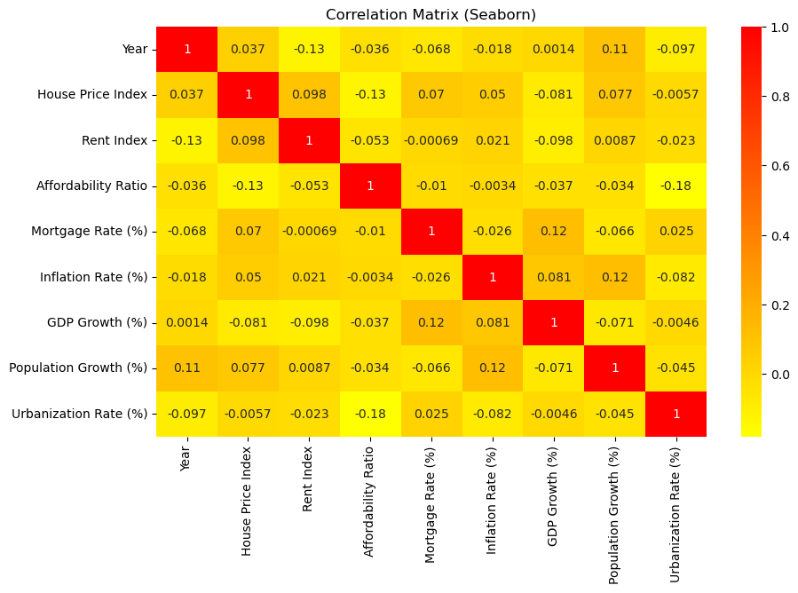

```python
numeric_df = df_cleaned.select_dtypes(include='number') # Only selecting numeric columns

plt.figure(figsize=(10, 6)) #setting size of graph
sns.heatmap(numeric_df.corr(), annot=True, cmap='autumn_r') #creating heatmap
plt.title("Correlation Matrix (Seaborn)") #label for title
plt.show() #display graph
```

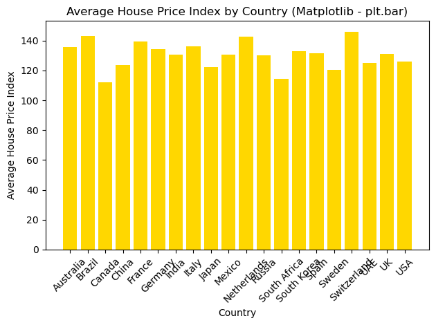

```python
plt.bar(house_indict2.index, house_indict2.values, color='gold') #constructing plot bar
plt.title("Average House Price Index by Country (Matplotlib - plt.bar)") #label title
plt.xlabel("Country") #label x-axis
plt.ylabel("Average House Price Index") #label y-axis
plt.xticks(rotation=45) #setting ticks of x-axis at an angle for easier readability
plt.tight_layout() #function that adjusts spacing
plt.show() #display graph
```

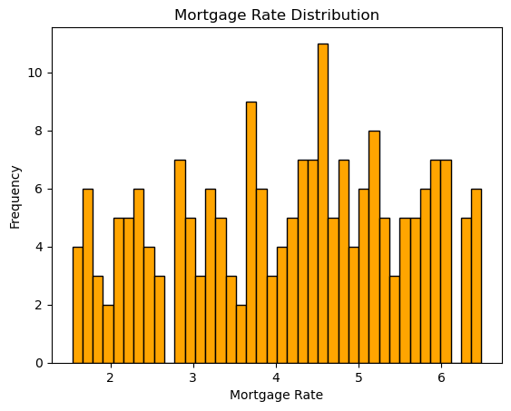

```python
plt.hist(df_cleaned['Mortgage Rate (%)'], bins=40, edgecolor='black', color='orange') #creating histogram
plt.xlabel("Mortgage Rate") #label for x-axis
plt.ylabel("Frequency") #label for y-axis
plt.title("Mortgage Rate Distribution") #titling of graph
#plt.savefig('Raven_Shaw_Project2_Histogram.jpg') #saving graph as a jpg on laptop
plt.show() #display graph
```

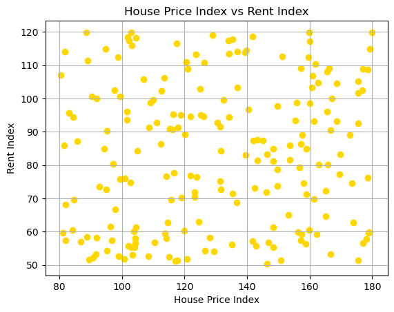

```python
plt.scatter(df_cleaned['House Price Index'], df_cleaned['Rent Index'], color='gold')
# Add labels and title
plt.title("House Price Index vs Rent Index") #label title
plt.xlabel("House Price Index")
plt.ylabel("Rent Index")

plt.grid(True)
plt.show()
```

*Analysis:* This scatter plot demonstrates the relationship between house price index and rent index, however it is evident that due to the lack of pattern between the data points, there is no relationship between these two columns/factors.

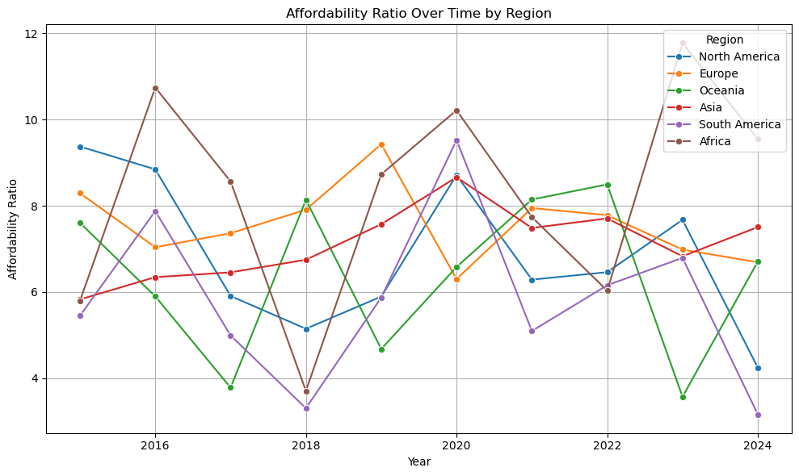

```python
plt.figure(figsize=(10, 6))
sns.lineplot(data=df_cleaned, x='Year', y='Affordability Ratio', hue='Region', marker='o', ci=None)

plt.title("Affordability Ratio Over Time by Region")
plt.xlabel("Year")
plt.ylabel("Affordability Ratio")
plt.legend(title='Region')
plt.grid(True)
plt.tight_layout()
plt.show()
```

*Analysis:* This lineplot demonstrates the change in affordability ratio over time by region. Evidently, the plot fluctuates across time regardless of regions. Africa has the largest fluctuations and Asia changes in the smallest increments.

```python
fig = px.choropleth(df_cleaned,
                     locations="Code",
                     color="House Price Index",
                     hover_name="Country",
                     animation_frame="Year",
                     projection="natural earth", #many options such as "orthographic", "equirectangular", "natural earth", "mercator". "miller". "robinson "
                     title="Average House Price Index by Country",
                     color_continuous_scale="thermal", #many options such as viridis, plasma, hot, ice, blues, reds, etc
                     range_color=(0,40),
                     height=600)
fig.update_layout(geo=dict(showframe=False, showcoastlines=True))
fig.show()
```

[interactive chart not shown]

*Analysis:* This geomap depicts the average house price index across the countries. Evidently, regardless of country they all have a high house price index.

#### **Section 5: Additional Project Specific Visualizations**

***Whereas the visualizations above where requested within the final project guidelines, the following visualizations are specific to my project regarding the pandemic***

```python
fig = px.scatter(
    df_2020,
    x='Inflation Rate (%)',
    y='GDP Growth (%)',
    size='Inflation Rate (%)',
    color='Region',
    hover_data=['Country', 'Code'],
    title='Bubble Chart: Inflation Rate vs GDP Growth in 2020 (Size = Inflation Rate, Color = Region)',
    color_continuous_scale='Viridis',  # Set your preferred color scale
    range_color=[0, 50]
)
plt.savefig('Raven_Shaw_FinalProject_IG_2020.jpg')
fig.show()
```

[interactive chart not shown]

```python
fig = px.scatter(
    df_2023,
    x='Inflation Rate (%)',
    y='GDP Growth (%)',
    size='Inflation Rate (%)',
    color='Region',
    hover_data=['Country', 'Code'],
    title='Bubble Chart: Inflation Rate vs GDP Growth in 2023 (Size = Inflation Rate, Color = Region)',
    color_continuous_scale='Viridis',  # Set your preferred color scale
    range_color=[0, 50]
)
plt.savefig('Raven_Shaw_FinalProject_IG_2023.jpg')
fig.show()
```

[interactive chart not shown]

***Key Takeaway 1:*** Between 2020 and 2023, more countries experienced negative GDP growth, reflecting the prolonged economic impact of the COVID-19 pandemic. This trend highlights that while some countries recovered quickly, many faced ongoing challenges such as inflation and reduced consumer spending.

```python
fig = px.scatter(
    df_2020,
    x='Urbanization Rate (%)',
    y='Population Growth (%)',
    color='Region',
    hover_data=['Country', 'Code'],
    size='Urbanization Rate (%)',
    size_max=20,
    title='Bubble Chart: Urbanization Rate vs Population Growth in 2020 (Size = Urbanization Rate, Color = Region)'
)
plt.savefig('Raven_Shaw_FinalProject_UP_2020.jpg')
fig.show()
```

[interactive chart not shown]

```python
fig = px.scatter(
    df_2023,
    x='Urbanization Rate (%)',
    y='Population Growth (%)',
    color='Region',
    hover_data=['Country', 'Code'],
    size='Urbanization Rate (%)',
    size_max=20,
    title='Bubble Chart: Urbanization Rate vs Population Growth in 2023 (Size = Urbanization Rate, Color = Region)'
)
plt.savefig('Raven_Shaw_FinalProject_UP_2023.jpg')
fig.show()
```

[interactive chart not shown]

***Key Takeaway 2:*** While urbanization rates increased globally, indicating a shift toward city living, population growth remained relatively stable. This suggests that while cities attracted more people, overall population numbers were held back by factors like migration restrictions.

```python
fig = px.scatter(
    df_2020,
    x='Affordability Ratio',
    y='Rent Index',
    color='Region',
    hover_data=['Country', 'Code'],
    size='Affordability Ratio',
    size_max=20,
    title='Bubble Chart: Affordability Ratio vs Rent Index in 2020 (Size = Affordability Ratio, Color = Region)'
)
plt.savefig('Raven_Shaw_FinalProject_AR_2020.jpg')
fig.show()
```

[interactive chart not shown]

```python
fig = px.scatter(
    df_2023,
    x='Affordability Ratio',
    y='Rent Index',
    color='Region',
    hover_data=['Country', 'Code'],
    size='Affordability Ratio',
    size_max=20,
    title='Bubble Chart: Affordability Ratio vs Rent Index in 2023 (Size = Affordability Ratio, Color = Region)'
)
plt.savefig('Raven_Shaw_FinalProject_AR_2023.jpg')
fig.show()
```

[interactive chart not shown]

***Key Takeaway 3:*** In 2020, only European countries had a lower affordability ratio, but by 2023, other regions like Asia, Oceania, and North America also saw more affordable housing. This shift was influenced by changing demand, remote work trends, and economic factors such as government interventions and inflation.